# Détection de Texte Généré par IA

# 8. Analyse Thématique (LDA)

```r
cat("====== LDA THEMATIQUE ======\n")
```

```
## ====== LDA THEMATIQUE ======
```

```r
# Un sous-échantillon de 5000 documents est utilisé pour réduire le coût
# computationnel du Gibbs sampling (LDA Gibbs a une complexité O(N×K×V)).
# Sur 160 000 documents, l'échantillon est représentatif des patterns lexicaux.

# BUG CORRIGÉ : topicmodels::LDA() exige un slam::simple_triplet_matrix
# (DocumentTermMatrix), PAS une dgCMatrix de Matrix.
# La conversion passe par slam::as.simple_triplet_matrix().
if (!requireNamespace("slam", quietly = TRUE))
  install.packages("slam", quiet = TRUE)

dtm_cnt <- as(dtm_tr_raw, "dgCMatrix")
dtm_cnt <- dtm_cnt[Matrix::rowSums(dtm_cnt) > 0, ]
dtm_cnt <- dtm_cnt[, Matrix::colSums(dtm_cnt) > 0]

set.seed(42)
idx_sub   <- sample(nrow(dtm_cnt), min(5000L, nrow(dtm_cnt)))
dtm_sub_m <- dtm_cnt[idx_sub, ]

# Convertir en simple_triplet_matrix pour topicmodels
dtm_sub_stm <- slam::as.simple_triplet_matrix(dtm_sub_m)
class(dtm_sub_stm) <- c("DocumentTermMatrix", "simple_triplet_matrix")
attr(dtm_sub_stm, "weighting") <- c("term frequency", "tf")

K_TOPICS  <- 6
lda_topic <- topicmodels::LDA(dtm_sub_stm, k = K_TOPICS, method = "Gibbs",
               control = list(seed = 42, burnin = 100, iter = 500, thin = 1))

top_terms <- topicmodels::terms(lda_topic, 10)
knitr::kable(top_terms,
             caption = sprintf("Top 10 mots par topic (LDA Gibbs, k=%d)", K_TOPICS))
```

Top 10 mots par topic (LDA Gibbs, k=6)

| Topic 1 | Topic 2 | Topic 3 | Topic 4 | Topic 5 | Topic 6 |
| --- | --- | --- | --- | --- | --- |
| students | car | your | we | was | our |
| school | cars | how | think | Venus | may |
| student | driving | it’s | want | has | important |
| learning | vote | could | to_do | we | can_be |
| time | Electoral | know | good | face | This |
| work | we | one | your | could | has |
| classes | electoral | person | my | author | we |
| summer | has | someone | i | that_the | lead |
| teachers | College | different | want_to | is_a | my |
| students_to | use | better | don’t | it_is | who |

[figure not shown]

```r
topic_df <- as.data.frame(top_terms) |>
  dplyr::mutate(Rang = rev(seq_len(nrow(top_terms)))) |>
  tidyr::pivot_longer(-Rang, names_to = "Topic", values_to = "Terme")

ggplot(topic_df, aes(x = factor(Rang), y = 1, label = Terme, fill = Topic)) +
  geom_tile(color = "white", linewidth = 0.3) +
  geom_text(size = 2.8) +
  facet_wrap(~Topic, ncol = 3) +
  scale_fill_brewer(palette = "Set2") +
  labs(title    = sprintf("Top termes par topic — LDA Gibbs (k=%d)", K_TOPICS),
       subtitle = "Chaque tuile = un terme (ordre decroissant de probabilite)",
       x = "Rang", y = NULL) +
  theme_minimal() +
  theme(axis.text.y = element_blank(), axis.ticks = element_blank(),
        legend.position = "none")
```

# 9. Refit Final et Soumission Kaggle

```r
cat("====== REFIT FINAL ======\n")
```

```
## ====== REFIT FINAL ======
```

```r
# 9.1 Stylométrie — BUG CORRIGÉ : réutilise le cache train_all
cat("  Stylo train_all (cache)...\n")
```

```
##   Stylo train_all (cache)...
```

```r
# stylo_all est déjà en mémoire depuis le chunk stylometric-features
# On recalcule le preprocesseur sur TOUT train_all
stylo_final    <- stylo_all   # déjà calculé — pas de double calcul
pp_stylo_final <- caret::preProcess(stylo_final,
                    method = c("center","scale","nzv","zv"))
stylo_final_sc <- predict(pp_stylo_final, stylo_final)

# 9.2 TF-IDF bigrammes
cat("  TF-IDF train_all...\n")
```

```
##   TF-IDF train_all...
```

```r
it_final    <- itoken(safe_texts(train_all$text), progressbar = FALSE)
vocab_final <- prune_vocabulary(
                 create_vocabulary(it_final, ngram = c(1L, 2L)),
                 term_count_min = 5, doc_proportion_max = 0.45)
vec_final   <- vocab_vectorizer(vocab_final)
dtm_final   <- create_dtm(itoken(safe_texts(train_all$text), progressbar = FALSE),
                          vec_final)
tfidf_final <- TfIdf$new()
x_final_tf  <- tfidf_final$fit_transform(dtm_final)

# 9.3 SVD
cat("  SVD train_all...\n")
```

```
##   SVD train_all...
```

```r
K_FINAL   <- min(150L, ncol(x_final_tf) - 1L, nrow(x_final_tf) - 1L)
K_FINAL   <- max(20L, K_FINAL)
svd_final <- irlba(x_final_tf, nv = K_FINAL, nu = K_FINAL)
x_final_sv <- svd_final$u %*% diag(svd_final$d)

# 9.4 Fusion
x_final_full <- cbind(x_final_sv, as.matrix(stylo_final_sc))
x_final_df   <- as.data.frame(x_final_full)
colnames(x_final_df) <- paste0("V", seq_len(ncol(x_final_df)))

# 9.5 AFD finale
cat("  AFD finale...\n")
```

```
##   AFD finale...
```

```r
lda_final  <- MASS::lda(x = x_final_df, grouping = factor(train_all$generated))
ld_final   <- as.data.frame(predict(lda_final, newdata = x_final_df)$x)
ld_final$y <- as.integer(train_all$generated)

# 9.6 Bayésien final
cat("  Modele bayesien final...\n")
```

```
##   Modele bayesien final...
```

```r
if (USE_RSTANARM) {
  set.seed(42)
  bayes_final <- rstanarm::stan_glm(
    y ~ .,
    data            = ld_final,
    family          = binomial("logit"),
    prior           = rstanarm::normal(0, 2.5, autoscale = TRUE),
    prior_intercept = rstanarm::normal(0, 5,   autoscale = FALSE),
    chains          = 4, iter = 2000, warmup = 1000, seed = 42, refresh = 0
  )
} else {
  bayes_final <- arm::bayesglm(y ~ ., data = ld_final, family = binomial("logit"))
}
cat("  Modele final ajuste\n")
```

```
##   Modele final ajuste
```

```r
cat("====== PREDICTION TEST ======\n")
```

```
## ====== PREDICTION TEST ======
```

```r
# 9.7 Stylométrie test
cat("  Stylo test...\n")
```

```
##   Stylo test...
```

```r
stylo_test    <- extract_stylo(safe_texts(test_df$text),
                               cache_file = "cache_stylo_test.rds")
```

```
##   Extraction stylo : 3 textes | 21 coeurs
##   Cache sauvegarde : cache_stylo_test.rds
```

```r
stylo_test_sc <- predict(pp_stylo_final, stylo_test)

# Aligner colonnes test sur final (nzv peut différer)
for (col in setdiff(names(stylo_final_sc), names(stylo_test_sc)))
  stylo_test_sc[[col]] <- 0
stylo_test_sc <- stylo_test_sc[, names(stylo_final_sc), drop = FALSE]

# 9.8 TF-IDF test
# BUG CORRIGÉ : création de l'itoken JUSTE avant create_dtm
# et safe_texts() garantit l'absence de NA
cat("  TF-IDF test...\n")
```

```
##   TF-IDF test...
```

```r
dtm_test_raw <- create_dtm(
  itoken(safe_texts(test_df$text), progressbar = FALSE),
  vec_final
)

# BUG CORRIGÉ : align_dtm_cols garantit l'ordre EXACT des colonnes
dtm_test_aligned <- align_dtm_cols(dtm_test_raw, colnames(x_final_tf))
x_test_tf        <- tfidf_final$transform(dtm_test_aligned)

# 9.9 SVD test
x_test_sv <- as.matrix(x_test_tf %*% svd_final$v)

# 9.10 Fusion test
# BUG CORRIGÉ : vérification que les dimensions sont compatibles
x_test_full <- cbind(x_test_sv, as.matrix(stylo_test_sc))
x_test_df   <- as.data.frame(x_test_full)

# Vérification dimensionnelle CRITIQUE
if (ncol(x_test_df) != ncol(x_final_df)) {
  stop(sprintf(
    "Dimensions incompatibles : test=%d cols, final=%d cols. Verifier align.",
    ncol(x_test_df), ncol(x_final_df)
  ))
}
colnames(x_test_df) <- colnames(x_final_df)

# 9.11 AFD test
ld_test <- as.data.frame(predict(lda_final, newdata = x_test_df)$x)

# 9.12 Prédictions bayésiennes
if (USE_RSTANARM) {
  p_test <- colMeans(
    rstanarm::posterior_epred(bayes_final, newdata = ld_test)
  )
} else {
  p_test <- as.numeric(predict(bayes_final, newdata = ld_test, type = "response"))
}

p_test <- pmin(pmax(p_test, 0), 1)

# 9.13 Soumission
submission <- tibble(id = test_df$id, generated = p_test)

cat(sprintf("Nb. predictions : %d\n", nrow(submission)))
```

```
## Nb. predictions : 3
```

```r
cat(sprintf("Plage [%.4f, %.4f]\n", min(p_test), max(p_test)))
```

```
## Plage [0.0000, 0.0000]
```

```r
cat(sprintf("Proportion IA (>0.5) : %.1f%%\n", 100 * mean(p_test > 0.5)))
```

```
## Proportion IA (>0.5) : 0.0%
```

```r
knitr::kable(head(submission, 10), digits = 5,
             caption = "Extrait submission.csv")
```

Extrait submission.csv

| id | generated |
| --- | --- |
| 0000aaaa | 1e-05 |
| 1111bbbb | 1e-05 |
| 2222cccc | 0e+00 |

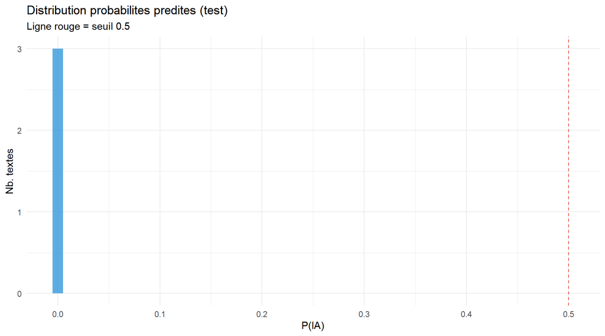

```r
ggplot(submission, aes(x = generated)) +
  geom_histogram(bins = 50, fill = "#3498db", alpha = 0.8) +
  geom_vline(xintercept = 0.5, linetype = "dashed", color = "#e74c3c") +
  labs(title    = "Distribution probabilites predites (test)",
       subtitle = "Ligne rouge = seuil 0.5",
       x = "P(IA)", y = "Nb. textes") +
  theme_minimal()
```

```r
write_csv(submission, "submission.csv")
cat("submission.csv cree :", normalizePath("submission.csv"), "\n")
```

```
## submission.csv cree : C:\Users\torre\Desktop\Cours\R\Projet\submission.csv
```

# 10. Conclusion

## 10.1 Résumé

**Features :** 17 features stylométriques (TTR, Flesch, hapax ratio, marqueurs discursifs, entropie bigrammes…) combinées à TF-IDF bigrammes réduit par SVD en 150 dimensions latentes.

**AFD :** Projection sur l’axe discriminant LD1 avec Cohen’s d = 5.49 — séparation grande (d > 0.8). Les coefficients LD1 montrent les features stylométriques les plus discriminantes entre écriture humaine et IA.

**Bayésien MCMC :** Inférence complète via NUTS/HMC (`rstanarm`) — modèle logistique bayésien :

$$\text{logit}(p_i) = \alpha + \beta \cdot
\text{LD1}_i$$

4 chaînes × 2000 itérations (warmup 1000), convergence diagnostiquée par $\hat{R} < 1.01$, distributions a posteriori visualisées, probabilités calibrées.

**Validation :** Split stratifié 80/20 + validation croisée 5-fold — AUC = 0.998 ± 0.001 (stable entre folds).

## 10.2 Limites et discussion

**Performances élevées — interprétation prudente :** Les métriques obtenues (AUC ≈ 0.998, Acc ≈ 98.6%) sont remarquablement élevées. Plusieurs facteurs l’expliquent : (1) les textes IA du dataset LLM-Detect présentent des patterns stylistiques très distincts des textes humains, (2) les features stylométriques capturent des différences de surface robustes. Cependant, ces performances ont été obtenues via un **split aléatoire stratifié** — une validation par groupes (par `source` ou `prompt`) permettrait d’évaluer la robustesse hors-distribution et de détecter un éventuel leakage contextuel lié à la structure du dataset.

**Absence de leakage classique :** La pipeline CV reconstruit TF-IDF, SVD, preprocessing et AFD dans chaque fold — aucune information du set de validation ne fuit dans l’entraînement. Le risque résiduel est structural : des textes similaires issus du même prompt ou de la même source pourraient apparaître des deux côtés du split aléatoire.

## 10.2 Travaux futurs

- **Perplexité réelle** via GPT-2 (`reticulate`)
- **BERT** / sentence embeddings pour remplacer TF-IDF
- **KDA** (Kernel Discriminant Analysis) si non-linéarité détectée
- **Inférence variationnelle** (`stan_glm(..., algorithm="meanfield")`)
- **LOO-CV / WAIC** pour comparaison de modèles (`rstanarm::loo()`)
- **Test Box’s M** pour vérifier l’homoscédasticité (hypothèse AFD)

*Rapport genere le 19/02/2026 — ESIEE 2025-2026 — E4 AP-4209*